# Bayesian Modelling of Urban Observatory Data

Jonny Law

10 January 2017

## Environment Sensors

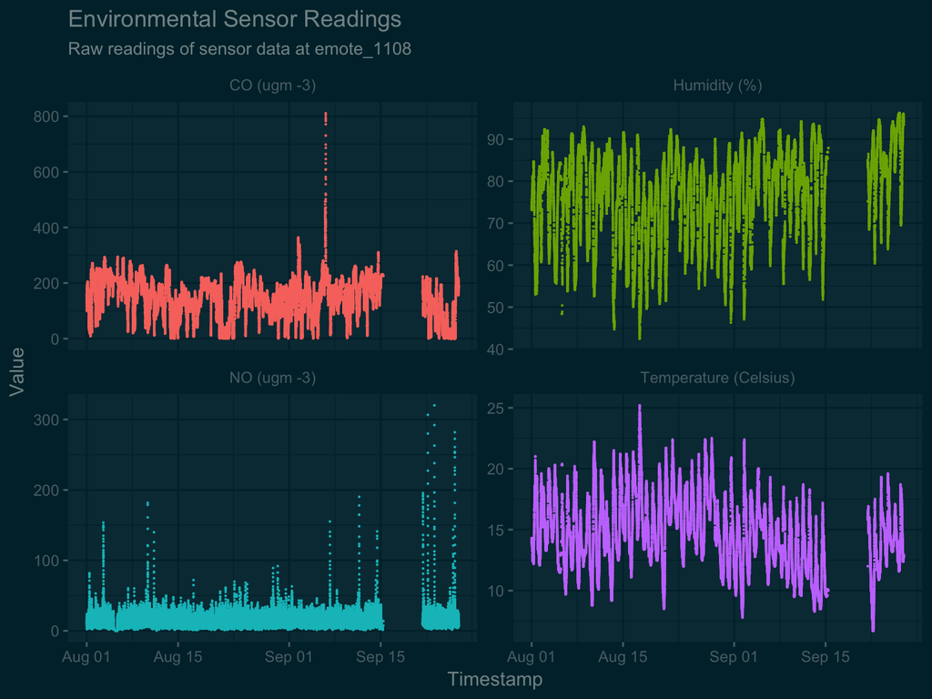

## A Naive Model

- Propose a state space model for each time series

$$\begin{aligned}
y_{ti} &= F_{ti}x_{ti} + v_{ti}, &v_{ti} &\sim \mathcal{N}(0, V_i), \\
x_{ti} &= G_{ti}x_{t-1} + w_{ti}, &w_{ti} &\sim \mathcal{N}(0, W_i), \\
x_0 &\sim p(x_0).
\end{aligned}$$

- Couple the models together using block diagonal matrices, for $i = 2$

$$F_t = \begin{bmatrix}F_{t1} &0 \\ 0 &F_{t2}\end{bmatrix}, G_t = \begin{bmatrix}G_{t1} & 0 \\ 0 & G_{t2}\end{bmatrix}.$$

## Learning Covariance Matrices

- In the Naive model the system covariance of the $i^{\textrm{th}}$ model has dimension $d_i \times d_i$
- If we model the four time series, the system covariance matrix contains $\sum_{i=1}^4 d_i^2$ terms
- *This is too large!*

## Factor Analysis

$$y_t = \beta^T f_t + \varepsilon_t, \quad \varepsilon_t \sim \mathcal{N}(0, \sigma_t)$$

- $y_t$ is a $p$-dimensional
- $\beta$ is a $k \times p$ matrix, $k << p$
- $f_t \sim \mathcal{N}(0, I_k)$ are latent variables
- $\operatorname{Var}(y_t) = \beta^\prime\beta + \sigma_t$

$$\beta^T = \begin{pmatrix}
1 & 0 \\
0.31 & 1 \\
0.27 & 0.84 \\
0.13 & 0.88 \\
0.43 & 0.77 \\
0.70 & 0.32
\end{pmatrix}$$

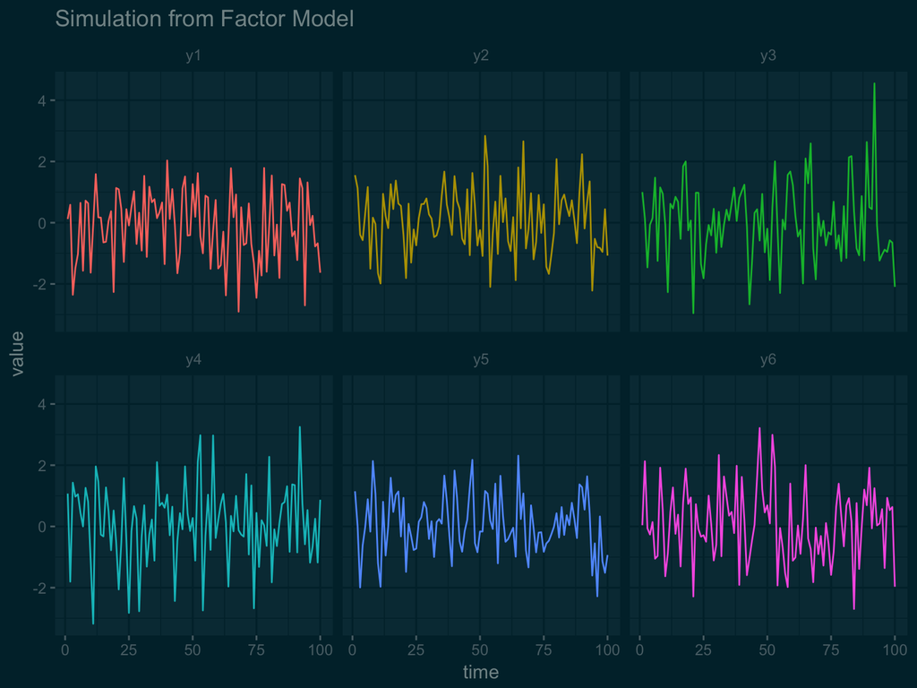

## Time Varying Variance: Stochastic Volatility Model

$$\begin{aligned}
y_t &= \varepsilon_t \exp(\alpha_t), &\varepsilon_t &\sim \mathcal{N}(0, 1) \\
\alpha_t &= \phi (\mu - \alpha_t) + \eta_t, &\eta_t &\sim \mathcal{N}(0, \sigma_\eta). \\
\alpha_0 &\sim p(\alpha_0).
\end{aligned}$$

- $y_t$ is a univariate time-series observed at times $t = t_0,\dots,t_T$
- $\alpha_t$ is the log-volatility, modelled using an AR(1) process
- Write this as $y_t \sim \textrm{ISV}_T(\phi; \sigma_\eta; \mu)$

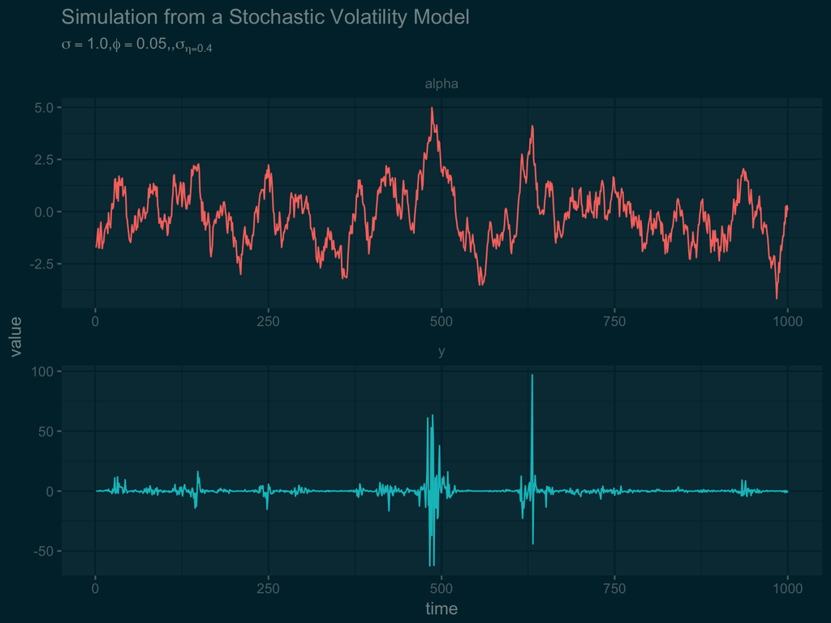

## Factor Stochastic Volatility

$$\begin{aligned}
y_t &= \beta f_t + v_t, \quad v_t \sim \mathcal{N}(0, V), \\
f_t &\sim \textrm{ISV}(\phi; \sigma_\eta; \mu).
\end{aligned}$$

- Combine factor analysis and stochastic volatility models to learn about many related processes with non-constant variance
- This model has fewer parameters than the naive model
- Parameter learning is performed using Gibbs Sampling and Kalman Filtering

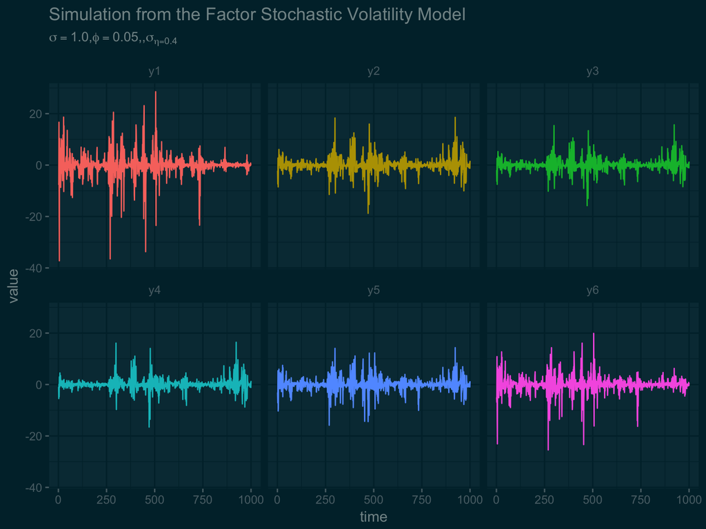

## Non Centered Factor SV

$$\begin{aligned}
y_t &= F_{t}\mu_{t} + \beta f_t + \varepsilon_t, &\varepsilon_t &\sim \mathcal{N}(0, \sigma) \\
x_t &= G_tx_{t-1} + w_{t}, &w_t &\sim \mathcal{N}(0, W) \\
f_t &\sim \textrm{ISV}(\phi; \sigma_\eta; \mu).
\end{aligned}$$

- A DLM is used to model the mean behaviour of each time series
- The matrices $F_t$ and $G_t$ are block diagonal
- $W = \operatorname{diag}(\sigma_{w,1}, \dots, \sigma_{w, pd})$

## Thanks

- Use my Scala package: Bayesian inference for D(G)LMs git.io/dlm
- Read our paper “Composable models for online Bayesian analysis of streaming data” published in Statistics and Computing (DOI 10.1007/s11222-017-9783-1.)